# Tarea 01_Zamora Mennigke_Ricardo

```r
apply(Datos2,1,mean,na.rm=T)
```

[output not shown]

[output cut: 244 more lines]

[output not shown]

```
##        Adam        Anna     Bernard      Edward      Emilia      Fabian
##          NA          NA          NA          NA          NA          NA
##      Philip       Frank      Xavier     Gabriel     Marisol       Henry
##          NA          NA          NA          NA          NA          NA
##       Irene    Isabelle     Isidore      Joseph      Eugene     Eugenia
##          NA          NA          NA          NA          NA          NA
##      Eunice         Eva     Evdokia       Fedir       Felix      Fialka
##          NA          NA          NA          NA          NA          NA
##      Flavia       Flora     Florent    Florence      Hannah       Helen
##          NA          NA          NA          NA          NA          NA
##      Herman      Hilary     Lourdes     Isadore        Ivan       Jacob
##          NA          NA          NA          NA          NA          NA
##    Jeremiah      Jervis     Joachim        John    Santiago   Josephine
##          NA          NA          NA          NA          NA          NA
##      Judith      Justin      Kalyna     Larissa    Lawrence        Leon
##          NA          NA          NA          NA          NA          NA
##     Leonard      Leonid       Lesia         Leo      Louise     Lubomyr
##          NA          NA          NA          NA          NA          NA
##       Lydia   Magdalyna      Maksym      Marcel    Margaret       Maria
##          NA          NA          NA          NA          NA          NA
##      Marian    Marianna     Markian       Marko      Martha      Martin
##          NA          NA          NA          NA          NA          NA
##      Maryna     Matthew       Maura        Maya Maximillian     Melania
##          NA          NA          NA          NA          NA          NA
##   Methodius     Michael  Michaelina        Mina      Monica      Mykyta
##          NA          NA          NA          NA          NA          NA
##       Myron    Myroslav   Myroslava      Salome      Samuel      Sandra
##          NA          NA          NA          NA          NA          NA
##       Sarah      Savina   Sebastian      Sophia     Stephan   Stephania
##          NA          NA          NA          NA          NA          NA
##     Susanna      Sylvan   Sylvester      Tamara    Theodore      Teofan
##          NA          NA          NA          NA          NA          NA
##      Teofil     Teofila        Teon      Teresa
##          NA          NA          NA          NA
```

```r
apply(Datos2,1,mean,na.rm=T)
```

[output not shown]

[output cut: 244 more lines]

[output not shown]

[output not shown]

##Ejercicio 10

###Usando el archivo de datos EjemploAlgoritmosRecomendacion.csv realice lo ###siguiente:

```r
Datos <- read.table("EjemploAlgoritmosRecomendacion.csv", header=TRUE,sep=";",dec=",",row.names=1)
str(Datos)
```

```
## 'data.frame':    100 obs. of  9 variables:
##  $ VelocidadEntrega: num  2.05 0.9 1.7 1.35 3 0.95 2.3 0.65 2.75 2 ...
##  $ Precio          : num  0.3 1.5 2.6 0.5 0.45 1.65 1.2 2.1 0.8 1.75 ...
##  $ Durabilidad     : num  3.45 3.15 2.85 3.55 4.8 3.95 4.75 3.1 4.7 3.25 ...
##  $ ImagenProducto  : num  2.35 3.3 3 2.95 3.9 2.4 3.3 2.55 2.35 3 ...
##  $ ValorEducativo  : num  2.4 2.5 4.3 1.8 3.4 2.6 3.5 2.8 3.5 3.7 ...
##  $ ServicioRetorno : num  2.3 4 2.7 2.3 4.6 1.9 4.5 2.2 3 3.2 ...
##  $ TamanoPaquete   : num  2.6 4.2 4.1 3.9 2.25 4.85 3.8 3.45 3.8 4.35 ...
##  $ Calidad.Producto: num  2.1 2.15 2.6 1.95 3.4 2.2 2.9 2.15 2.7 2.7 ...
##  $ NumeroEstrellas : num  1.7 2.8 3.3 1.7 4.3 3 3.1 2.9 4.8 3.9 ...
```

###Grafique usando los comandos plot y qplot en el plano XY las variables ###Entrega vs Precio.

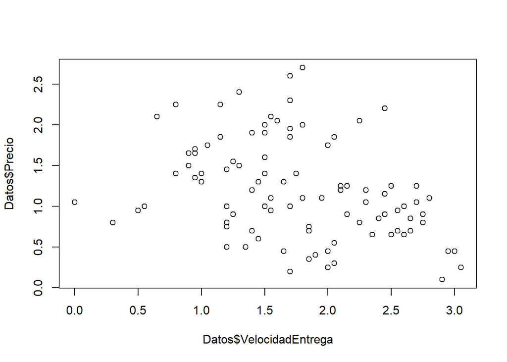

```r
library(ggplot2)
plot(Datos$VelocidadEntrega,Datos$Precio)
```

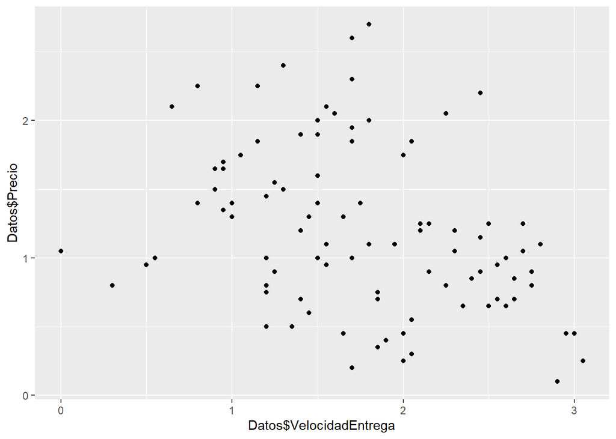

```r
qplot(Datos$VelocidadEntrega,Datos$Precio)
```

###Grafique usando comando scatterplot3d en 3 dimensiones las variables ###Entrega, Precio y Durabilidad.

```r
library(scatterplot3d)
library(rgl)
```

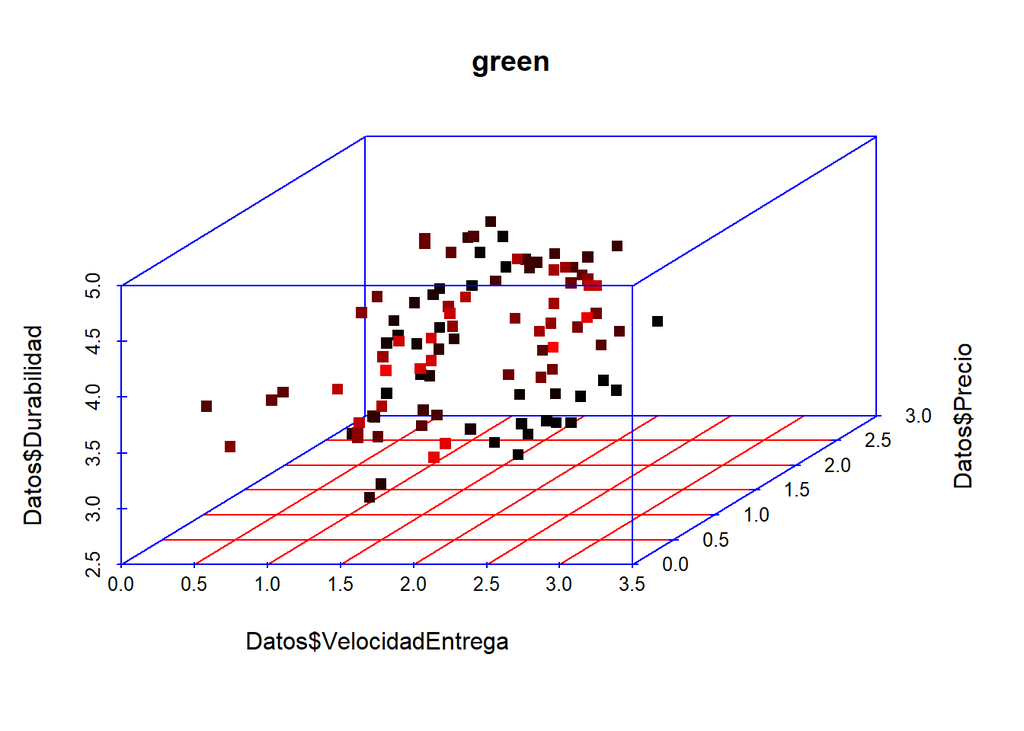

```r
scatterplot3d(Datos$VelocidadEntrega, Datos$Precio, Datos$Durabilidad, highlight.3d = TRUE, col.axis = "blue", col.grid = "red", main = "green", pch = 15)
```

###Usando el comando cor calcule la matriz de correlaciones de la tabla ###EjemploAlgoritmosRecomendacion.csv y grafique esta matriz de 4 formas ###diferentes.

```r
cor(Datos)
```

```
##                  VelocidadEntrega      Precio Durabilidad ImagenProducto
## VelocidadEntrega       1.00000000 -0.34922515  0.50929519      0.0504142
## Precio                -0.34922515  1.00000000 -0.48721259      0.2721868
## Durabilidad            0.50929519 -0.48721259  1.00000000     -0.1161041
## ImagenProducto         0.05041420  0.27218676 -0.11610408      1.0000000
## ValorEducativo         0.61190069  0.51298082  0.06661728      0.2986774
## ServicioRetorno        0.07711522  0.18624325 -0.03431610      0.7882245
## TamanoPaquete         -0.48263094  0.46974578 -0.44811201      0.1999811
## Calidad.Producto       0.65063233  0.02839467  0.52481415      0.4759338
## NumeroEstrellas        0.67646626  0.08191709  0.55903893      0.2241884
##                  ValorEducativo ServicioRetorno TamanoPaquete Calidad.Producto
## VelocidadEntrega     0.61190069      0.07711522    -0.4826309       0.65063233
## Precio               0.51298082      0.18624325     0.4697458       0.02839467
## Durabilidad          0.06661728     -0.03431610    -0.4481120       0.52481415
## ImagenProducto       0.29867737      0.78822454     0.1999811       0.47593383
## ValorEducativo       1.00000000      0.24080818    -0.0551613       0.63123290
## ServicioRetorno      0.24080818      1.00000000     0.1772939       0.34090930
## TamanoPaquete       -0.05516130      0.17729392     1.0000000      -0.28333980
## Calidad.Producto     0.63123290      0.34090930    -0.2833398       1.00000000
## NumeroEstrellas      0.70069608      0.25605904    -0.1924665       0.71069754
##                  NumeroEstrellas
## VelocidadEntrega      0.67646626
## Precio                0.08191709
## Durabilidad           0.55903893
## ImagenProducto        0.22418841
## ValorEducativo        0.70069608
## ServicioRetorno       0.25605904
## TamanoPaquete        -0.19246648
## Calidad.Producto      0.71069754
## NumeroEstrellas       1.00000000
```

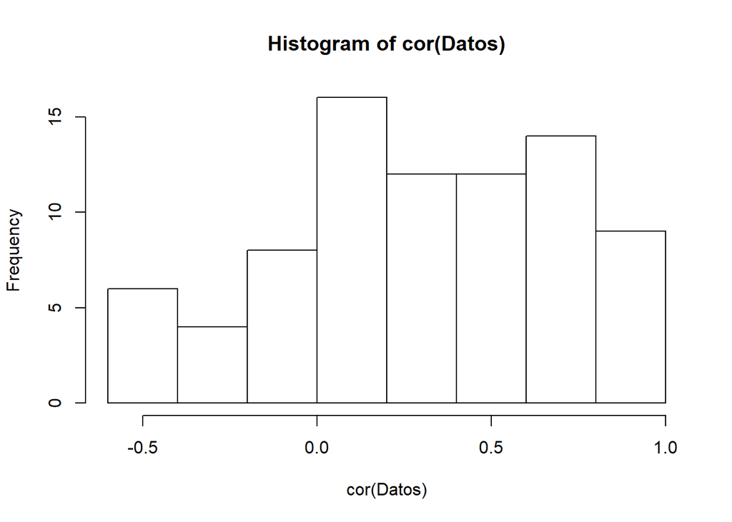

```r
hist(cor(Datos))
```

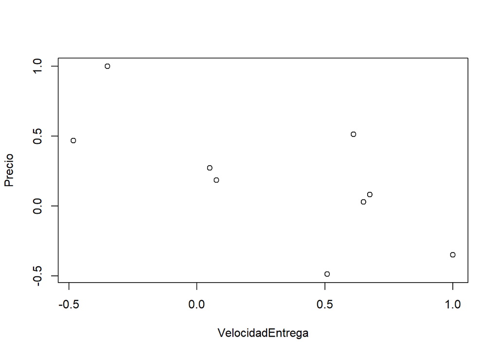

```r
plot(cor(Datos))
```

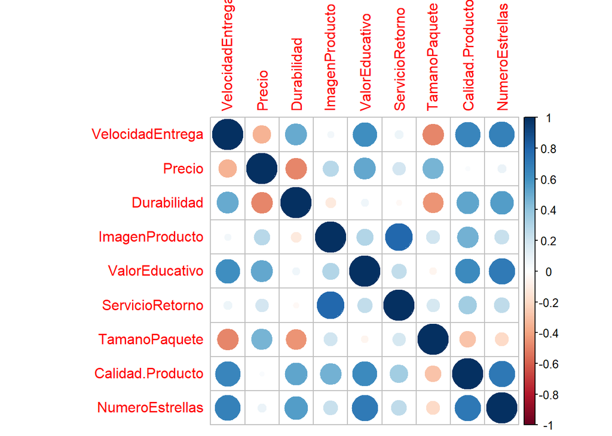

```r
library(corrplot)
corrplot(cor(Datos))
```

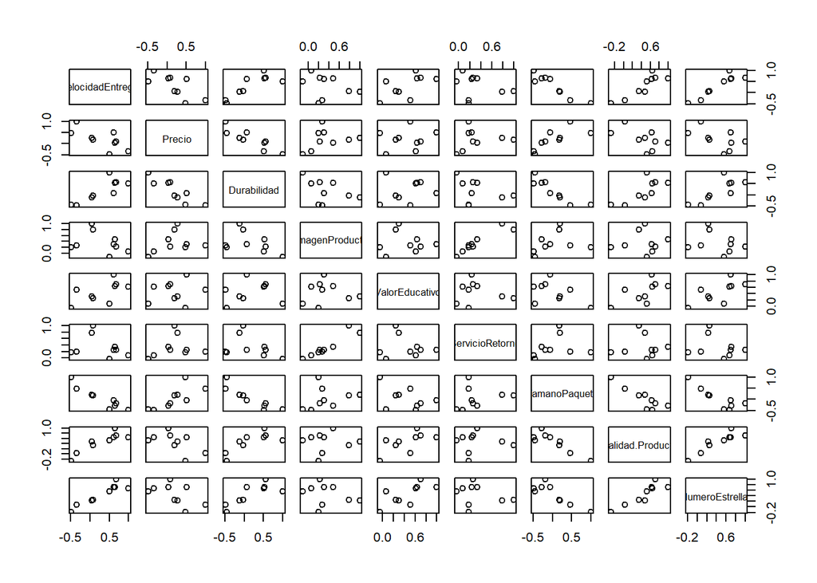

```r
pairs(cor(Datos))
```